# dplyr tutorial

James Ball

27/07/2020

# dplyr intro

## dplyr basics

First we’ll look at three key `dplyr` functions for basic data manipulation:

- Pick observations by their values with `filter()`
- Create new variables with functions of existing variables with `mutate()`.
- Collapse many values down to a single summary `summarize()`.

These can all be used in conjunction with `group_by()` which changes the scope of each function from operating on the entire dataset to operating on it group-by-group.

All `dplyr` verbs work similarly:

1. The first argument is a data frame
2. The subsequent arguments describe what to do with the data frame
3. The result is a new data frame

See the [data transformation cheatsheet](https://github.com/rstudio/cheatsheets/blob/master/data-transformation.pdf) for help.

we will use the `dplyr` package and example data from `nycflights13`

```r
library(dplyr)
library(ggplot2)
#install.packages("nycflights13")
library(nycflights13)
```

Take a look at the data

```r
head(flights)
```

```
## # A tibble: 6 x 19
##    year month   day dep_time sched_dep_time dep_delay arr_time sched_arr_time
##   <int> <int> <int>    <int>          <int>     <dbl>    <int>          <int>
## 1  2013     1     1      517            515         2      830            819
## 2  2013     1     1      533            529         4      850            830
## 3  2013     1     1      542            540         2      923            850
## 4  2013     1     1      544            545        -1     1004           1022
## 5  2013     1     1      554            600        -6      812            837
## 6  2013     1     1      554            558        -4      740            728
## # ... with 11 more variables: arr_delay <dbl>, carrier <chr>, flight <int>,
## #   tailnum <chr>, origin <chr>, dest <chr>, air_time <dbl>, distance <dbl>,
## #   hour <dbl>, minute <dbl>, time_hour <dttm>
```

Q1/ Can you use `filter()` to inspect flights from the first day of the year? (hint: use `month ==` and `day ==`)? (Use a pipe to pass the data into the filter function)

```
## # A tibble: 842 x 19
##     year month   day dep_time sched_dep_time dep_delay arr_time sched_arr_time
##    <int> <int> <int>    <int>          <int>     <dbl>    <int>          <int>
##  1  2013     1     1      517            515         2      830            819
##  2  2013     1     1      533            529         4      850            830
##  3  2013     1     1      542            540         2      923            850
##  4  2013     1     1      544            545        -1     1004           1022
##  5  2013     1     1      554            600        -6      812            837
##  6  2013     1     1      554            558        -4      740            728
##  7  2013     1     1      555            600        -5      913            854
##  8  2013     1     1      557            600        -3      709            723
##  9  2013     1     1      557            600        -3      838            846
## 10  2013     1     1      558            600        -2      753            745
## # ... with 832 more rows, and 11 more variables: arr_delay <dbl>,
## #   carrier <chr>, flight <int>, tailnum <chr>, origin <chr>, dest <chr>,
## #   air_time <dbl>, distance <dbl>, hour <dbl>, minute <dbl>, time_hour <dttm>
```

To filter the flights for November and December, you can use the `|` (“or”) logical operator

```r
flights %>%
  filter(month == 11 | month == 12)
```

```
## # A tibble: 55,403 x 19
##     year month   day dep_time sched_dep_time dep_delay arr_time sched_arr_time
##    <int> <int> <int>    <int>          <int>     <dbl>    <int>          <int>
##  1  2013    11     1        5           2359         6      352            345
##  2  2013    11     1       35           2250       105      123           2356
##  3  2013    11     1      455            500        -5      641            651
##  4  2013    11     1      539            545        -6      856            827
##  5  2013    11     1      542            545        -3      831            855
##  6  2013    11     1      549            600       -11      912            923
##  7  2013    11     1      550            600       -10      705            659
##  8  2013    11     1      554            600        -6      659            701
##  9  2013    11     1      554            600        -6      826            827
## 10  2013    11     1      554            600        -6      749            751
## # ... with 55,393 more rows, and 11 more variables: arr_delay <dbl>,
## #   carrier <chr>, flight <int>, tailnum <chr>, origin <chr>, dest <chr>,
## #   air_time <dbl>, distance <dbl>, hour <dbl>, minute <dbl>, time_hour <dttm>
```

Alternatively, it can be useful to use the `%in%` operator

```r
flights %>%
  filter(month %in% c(11, 12))
```

```
## # A tibble: 55,403 x 19
##     year month   day dep_time sched_dep_time dep_delay arr_time sched_arr_time
##    <int> <int> <int>    <int>          <int>     <dbl>    <int>          <int>
##  1  2013    11     1        5           2359         6      352            345
##  2  2013    11     1       35           2250       105      123           2356
##  3  2013    11     1      455            500        -5      641            651
##  4  2013    11     1      539            545        -6      856            827
##  5  2013    11     1      542            545        -3      831            855
##  6  2013    11     1      549            600       -11      912            923
##  7  2013    11     1      550            600       -10      705            659
##  8  2013    11     1      554            600        -6      659            701
##  9  2013    11     1      554            600        -6      826            827
## 10  2013    11     1      554            600        -6      749            751
## # ... with 55,393 more rows, and 11 more variables: arr_delay <dbl>,
## #   carrier <chr>, flight <int>, tailnum <chr>, origin <chr>, dest <chr>,
## #   air_time <dbl>, distance <dbl>, hour <dbl>, minute <dbl>, time_hour <dttm>
```

## New variables with `mutate()`

To create a more managable Tibble we will use the `select()` function to choose the variables that are of interest to us. Note the use of `ends_withs()` to select multiple relevant variables.

```r
flights_sml <-
  flights %>%
  select(
    year:day,
    ends_with("delay"),
    distance,
    air_time
  )
flights_sml
```

```
## # A tibble: 336,776 x 7
##     year month   day dep_delay arr_delay distance air_time
##    <int> <int> <int>     <dbl>     <dbl>    <dbl>    <dbl>
##  1  2013     1     1         2        11     1400      227
##  2  2013     1     1         4        20     1416      227
##  3  2013     1     1         2        33     1089      160
##  4  2013     1     1        -1       -18     1576      183
##  5  2013     1     1        -6       -25      762      116
##  6  2013     1     1        -4        12      719      150
##  7  2013     1     1        -5        19     1065      158
##  8  2013     1     1        -3       -14      229       53
##  9  2013     1     1        -3        -8      944      140
## 10  2013     1     1        -2         8      733      138
## # ... with 336,766 more rows
```

Now we would like to create some new variables

```r
flights_sml %>%
  mutate(
    gain = arr_delay - dep_delay
  )
```

```
## # A tibble: 336,776 x 8
##     year month   day dep_delay arr_delay distance air_time  gain
##    <int> <int> <int>     <dbl>     <dbl>    <dbl>    <dbl> <dbl>
##  1  2013     1     1         2        11     1400      227     9
##  2  2013     1     1         4        20     1416      227    16
##  3  2013     1     1         2        33     1089      160    31
##  4  2013     1     1        -1       -18     1576      183   -17
##  5  2013     1     1        -6       -25      762      116   -19
##  6  2013     1     1        -4        12      719      150    16
##  7  2013     1     1        -5        19     1065      158    24
##  8  2013     1     1        -3       -14      229       53   -11
##  9  2013     1     1        -3        -8      944      140    -5
## 10  2013     1     1        -2         8      733      138    10
## # ... with 336,766 more rows
```

Here we have created the variable `gain` which tells us the difference between the arrival delay and the departure delay.

Q2/ How would you create a new variable that tells us the average speed during the flight (`speed`)

```
## # A tibble: 336,776 x 9
##     year month   day dep_delay arr_delay distance air_time  gain speed
##    <int> <int> <int>     <dbl>     <dbl>    <dbl>    <dbl> <dbl> <dbl>
##  1  2013     1     1         2        11     1400      227     9  370.
##  2  2013     1     1         4        20     1416      227    16  374.
##  3  2013     1     1         2        33     1089      160    31  408.
##  4  2013     1     1        -1       -18     1576      183   -17  517.
##  5  2013     1     1        -6       -25      762      116   -19  394.
##  6  2013     1     1        -4        12      719      150    16  288.
##  7  2013     1     1        -5        19     1065      158    24  404.
##  8  2013     1     1        -3       -14      229       53   -11  259.
##  9  2013     1     1        -3        -8      944      140    -5  405.
## 10  2013     1     1        -2         8      733      138    10  319.
## # ... with 336,766 more rows
```

## Grouped summaries

The verb `summarize()` collapses a data frame to a single row. For examples, we can use it to calculate the average delay.

```r
flights %>%
  summarize(delay = mean(dep_delay, na.rm = TRUE))
```

```
## # A tibble: 1 x 1
##   delay
##   <dbl>
## 1  12.6
```

We can combine it with `group_by()` which changes the unit of analysis from the complete dataset to individual groups.

How would you create a data frame that tells you the average delay in each month? (hint: use two pipe operations)

```
## # A tibble: 12 x 3
## # Groups:   year [1]
##     year month delay
##    <int> <int> <dbl>
##  1  2013     1 10.0
##  2  2013     2 10.8
##  3  2013     3 13.2
##  4  2013     4 13.9
##  5  2013     5 13.0
##  6  2013     6 20.8
##  7  2013     7 21.7
##  8  2013     8 12.6
##  9  2013     9  6.72
## 10  2013    10  6.24
## 11  2013    11  5.44
## 12  2013    12 16.6
```

## Extension exercise

Imagine that we want to explore the relationship between the distance and average delay for each location.

To prepare this data we can:

1. Use `group_by()` to group flights by destination.
2. Use `summarize()` to count the flights for each destination and calculate the mean distance and arrival delay e.g.

```
summarize(
  by_dest,
  count = n(),
  dist = mean(distance, na.rm = TRUE),
  delay = mean(arr_delay, na.rm = TRUE)
)
```

3. Filter to remove noisy points and Honolulu airport, which is almost twice as far away as the next closest airport.

```
delay <- filter(delay, count > 20, dest != "HNL")
```

We can then use ggplot to display these results.

How can we combine these operations using pipes (`%>%`)?

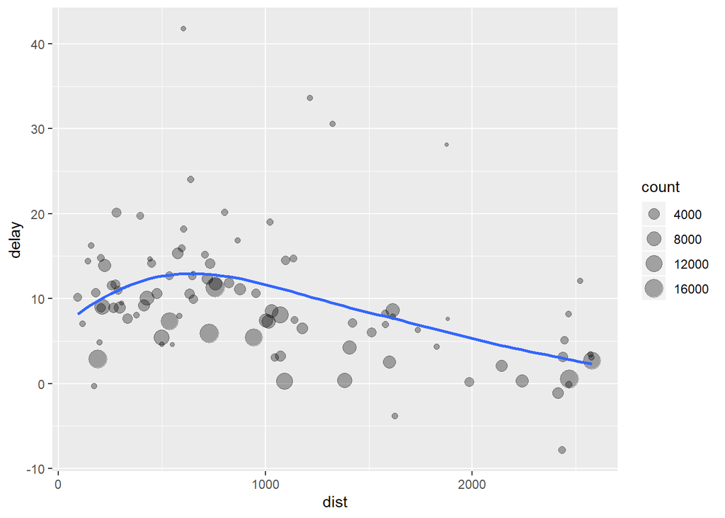

See [Data Challenge Lab](https://dcl-wrangle.stanford.edu/) for solutions.